# EFORTles Assessment

Daniel DeWaters

10/25/2020

This is a writeup document for the assessment given by Efortles Inc. I chose to implement my solution to the coding challenge with R as it is the easiest language to document and share an analysis through the use of R Markdown.

# Finding the Busiest Station in December 2016

## Getting the data

I downloaded the data and used the `read_delim` function from the `readr` package to read it in. This package is nice for selecting which columns to read in and setting their type easily.

```r
# download file
download.file("http://web.mta.info/developers/data/nyct/turnstile/turnstile_161224.txt",
              destfile = "data/turnstile_161224.txt")

# Read in file
station_data <- read_delim("data/turnstile_161224.txt", delim=",", trim_ws=TRUE,
                           # Read in only the station, entries, and exits columns,
                           # and set their type
                           col_types=cols_only("STATION"=col_character(),
                                          "ENTRIES"=col_number(),
                                          "EXITS"=col_number()))
```

## Calculating the Busiest Station

After reading in the data I used the `group_by` and `summarise` functions from the `dplyr` package to calculate the sum of entries and exits for each station and sort them in descending order to get the top sums of entries and exits.

```r
busiest_stations <-
  station_data %>%
  # Get the sum of each station's entries and exits
  group_by(STATION) %>%
  summarise(sum_entries=sum(ENTRIES), sum_exits=sum(EXITS), .groups="drop") %>%
  # Sort by descending order of entries, then by descending order of exits
  arrange(desc(sum_entries), desc(sum_exits))

head(busiest_stations)
```

```
## # A tibble: 6 x 3
##   STATION          sum_entries    sum_exits
##   <chr>                  <dbl>        <dbl>
## 1 42 ST-PORT AUTH 316902103019 260555918711
## 2 125 ST          291276298390 166439786900
## 3 23 ST           273635974527 254184602851
## 4 CANAL ST        253470306707 252678618530
## 5 TIMES SQ-42 ST  240432487850 189359465518
## 6 104 ST          209216934068 213102891164
```

# Finding the 5 Least Busy Stations

## Web Scraping for download links

I used the `rvest` package to read in the html source and grab the links for downloading the data. I created a data frame that had one column for the data file links and a column for the corresponding date.

```r
# Read in html source
my_url = "http://web.mta.info/developers/turnstile.html"
page <- read_html(my_url)

# Get dates and corresponding download links for the data
page_text <-
  page %>%
  html_nodes("a") %>%
  html_text()

page_links <-
  page %>%
  html_nodes("a") %>%
  html_attr("href")

# combine links and dates into single data frame
data_links <- as.data.frame(cbind(page_text, page_links))
colnames(data_links) <- c("date", "links")

# Display a few rows of the data frame
data_links[38:42,]
```

```
##                           date                                    links
## 38 Saturday, November 14, 2020 data/nyct/turnstile/turnstile_201114.txt
## 39 Saturday, November 07, 2020 data/nyct/turnstile/turnstile_201107.txt
## 40  Saturday, October 31, 2020 data/nyct/turnstile/turnstile_201031.txt
## 41  Saturday, October 24, 2020 data/nyct/turnstile/turnstile_201024.txt
## 42  Saturday, October 17, 2020 data/nyct/turnstile/turnstile_201017.txt
```

The data frame created in the previous code chunk needed to be tidied a bit before I could download any of the data files. I removed the URLs that didn’t lead to the data files, added a column for the file names of the files to be downloaded, and completed the URLs in the “links” column. Finally, I formatted the dates column and removed any URLs for files that weren’t from 2014 to 2016.

```r
data_links_clean <-
  data_links %>%
  # Remove any links that aren't for the data
  filter(grepl("data", links)) %>%
  # fix file paths
  mutate(filenames = sub("data/nyct/turnstile/", "data/", links)) %>%
  # Complete url
  mutate(links = paste0("http://web.mta.info/developers/", links)) %>%
  # Clean dates column and filter out files that aren't for 2014-2016
  mutate(date = sub("^Saturday, ", "", date)) %>%
  mutate(date = mdy(date)) %>%
  filter(year(date) >= 2014 & year(date) <= 2016)

# Grab urls and file paths to facilitate download code
download_links <- data_links_clean$links
filenames <- data_links_clean$filenames
```

## Downloading and Reading in the Data

I used a loop to download each file.

```r
# Download each file from 2014-2016
for(i in 1:dim(data_links_clean)[1]){
  download.file(download_links[i], destfile = filenames[i])
}
```

I read in each file into a data frame using a loop, and appended each new file to a data frame as they were read in.

```r
# Initialize empty data frame
station_data <- data.frame(matrix(ncol=3, nrow=0))

for(i in 1:length(filenames)){
  # Read in new file
  new_df <- read_delim(filenames[i], delim=",", trim_ws=TRUE,
                       col_types=cols_only("STATION"=col_character(),
                                           "ENTRIES"=col_number(),
                                           "EXITS"=col_number()))
  # Append new file to data frame
  station_data <- rbind(station_data, new_df)
}
```

## Calculate Sums of Entries and Exits

```r
# Calculate sums of entries and exits for each station
station_data_totals <-
  station_data %>%
  group_by(STATION) %>%
  summarize(sum_entries=sum(ENTRIES), sum_exits=sum(EXITS), .groups="drop")

# Get the 5 stations with the least entries
least_entries <-
  station_data_totals %>%
  select(STATION, sum_entries) %>%
  top_n(sum_entries, n=-5) %>%
  arrange(sum_entries) %>%
  mutate(STATION=as.factor(STATION))

# Get the 5 stations with the least exits
least_exits <-
  station_data_totals %>%
  select(STATION, sum_exits) %>%
  top_n(sum_exits, n=-5) %>%
  arrange(sum_exits) %>%
  mutate(STATION=as.factor(STATION))
```

## Making a Barplot

I used the `ggplot2` package to create the bar plots.

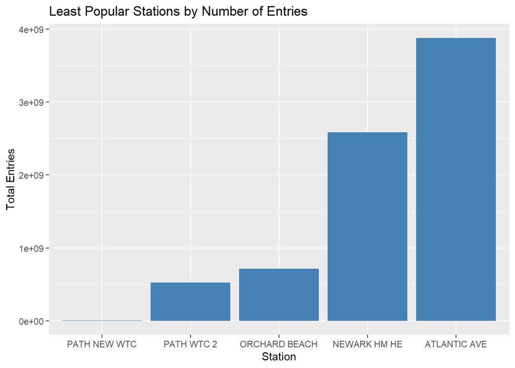

```r
least_entries %>%
  ggplot(aes(x=reorder(STATION, sum_entries), y=sum_entries)) +
  geom_bar(stat="identity", fill="steelblue") +
  xlab("Station") + ylab("Total Entries") +
  ggtitle("Least Popular Stations by Number of Entries")
```

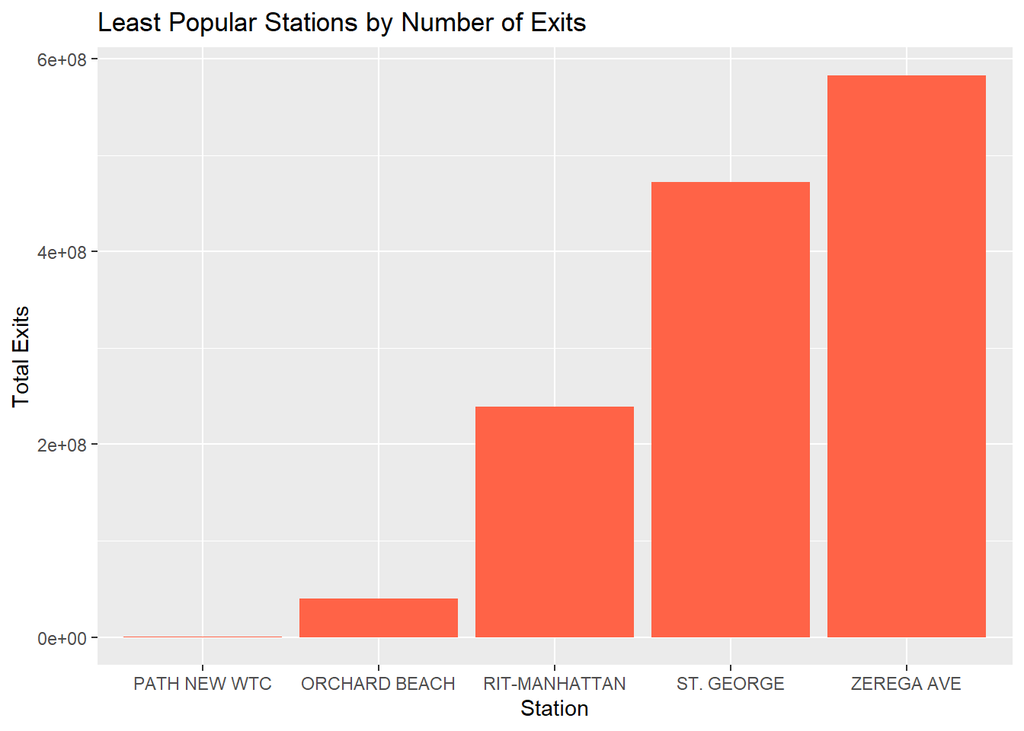

```r
least_exits %>%
  ggplot(aes(x=reorder(STATION, sum_exits), y=sum_exits)) +
  geom_bar(stat="identity", fill="tomato") +
  xlab("Station") + ylab("Total Exits") +
  ggtitle("Least Popular Stations by Number of Exits")
```

## Conclusions

The resulting bar graphs show that the 5 stations with the least number of entries are “Path New WTC”, “Path WTC 2”, “Orchard Beach”, “Newark HM HE”, and “Atlantic AVE”. The 5 stations with the least number of exits are “Path New WTC”, “Orchard Beach”, “Rit-Manhattan”, “St. George”, and “Zerega Ave”.

# Contact Information

Thank you for reading my assessment. I had a lot of fun completing it. Please feel free to call me at 434-362-0601 or email me to set up a call at dandewaters@gmail.com. If I am not a fit for this specific opportunity, I am flexible and willing to take other positions that may better fit my qualifications. I hope to hear from you soon!